# 2. Intro to Rmd files and literate programming

Julia Cancro

Last compiled on 21 July, 2023 09:25

Rmd files differ from R files in that they combine regular text with code chunks. This is a code chunk

```r
print("this is a chunk")
```

```
## [1] "this is a chunk"
```

Code chunks combine code with output. When combined with regular text/prose, this makes it easier to produce a range of documents. You set the output in the YAML header (the stuff between the 3 dashes you see at top of this document).

After you write the file, you **Knit** it to turn the Rmd file into the selected output. Try it now. Note the first time you do this in a project you may be prompted to install a number of packages! If you are using a webservice you may also need to allow pop-ups in your browser. Don’t be surprised if a new window pops up (it should).

[figure not shown]

The knit button turns your .rmd file into other products

The **Knit** button saves the .Rmd file and renders a new version whose output depends on what you selected in the header. Here we have html_document, so if everything works a preview of a webpage like document should appear. The file also produces a github friendly .md file. **This means you should only edit the Rmd file (leave the md and output files alone! They are automatically produced any changes you make there will be overwritten by your next knit)**.

When you **Knit** a file, it runs in a totally new R instance. this means anything you only added in your instance (like working in the console) won’t be available. In other words, its the best way to see what a “new” user gets when they use your code.

however, you don’t have to knit the file every time. if you just want to see output, note you can press the green button next to an R chunk.

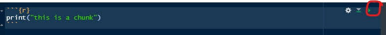

The green arrows just runs the chunk in the console and shows the output

```r
print("this is a chunk")
```

```
## [1] "this is a chunk"
```

Now we’ll start changing the file to show you how rmarkdown works. First, amend the file by replacing the **NAME** and **DATE** spots in the header (top of the file between the — markers) with your name and the real date. Then **Knit** the file again. You should see your name in the new preview.

Rstudio has a **Markdown Quick Reference** guide (look under the help tab), but some general notes.

- Pound/Hashtag signs denote headers
- you can surround something double asterisks for bold or single asterisks for italics
- lists are denoted by numbers or asterisks at beginning of line (followed by space!)
  - and can be indented for sublevels
- R code can be done inline, but is generally placed in stand-alone chunks
  - these will, by default, show the code and output
- lots of other options exist!

The main idea is Rmd files allow you to combine code, text, graphs, etc into multiple outputs that you can share (including with coding illiterate colleagues who just want output).

To practice working with Rmd files and R, work through the questions below. You can also get more help with [this video](https://www.youtube.com/watch?v=shs95EH4EhY&list=PLmnVhyQ-20EUFRmsjpYTyB5--zyolr6-o&index=9&t=24s)

### R subtleties and functions

1. Let x be defined by

```r
x <- 5:15
```

This will run the code in the Console. You may need to switch to Console (from Rmarkdown) in the lower right window area to see this. The executed code is also displayed in your processed file (hit **Knit** again to see this!).

Note running this chunk has added an object named `x` to the **Environment** tab area (top right area of screen). But nothing was “returned” in the console. You prove this by typing `x` in the console. What does it return?

2. Now try to guess the output of these commands
- length(x)
- max(x)
- x[x < 10]
- x^2
- x[ x < 12 & x > 7]

### Data input, plotting, and tests

You can read in a dataset from the internet following this protocol.

```r
sleep <- read.csv("http://raw.githubusercontent.com/jsgosnell/CUNY-BioStats/master/datasets/sleep.csv", stringsAsFactors = T)
```

Run this chunk and note it has added an object named `sleep` to the environment.

Info on the dataset is viewable @ http://www.statsci.org/data/general/sleep.html.

4. How many rows does the **sleep** data set have (hint: `?dim`)? What kind of data is stored in each variable?

5. Change the column named *BodyWt* to *Body_weight*”* in the sleep dataset.

6. Produce a plot of how *TotalSleep* differs between primates and other species. What is this plot showing?

Note, as of early 2020 R no longer reads in strings as factors! This means the Primate column, which is full of “Yes”s and “No”s, reads in as words and R doesn’t know how to plot them. There are many ways to handle this. You can modify the read.csv command (add stringsAsFactors = T option), eg

```r
sleep <- read.csv("http://raw.githubusercontent.com/jsgosnell/CUNY-BioStats/master/datasets/sleep.csv", stringsAsFactors = T)
```

If you do this, you’ll need to rechange anything you previously updated to the object (like renaming the BodyWt column).

You can also modify a single column for the actual object

```r
sleep$Primate <- factor (sleep$Primate)
```

or for a single command, eg (plot not actually shown!)

```r
plot(BodyWt ~ factor(Primate), data = sleep)
```

7. The **sleep** dataset begs to have a linear model fit for it. Let’s consider. First plot how *TotalSleep* is explained by *BrainWt*. Are there any issues with the data? Exclude any outlier and fit a linear model to obtain the p-value for the model (hint: summary()). What does this imply?